# Miniproject: Image Classification

### Description

One of the oldest traditions in deep learning is to first tackle the fun problem of MNIST classification. [The MNIST dataset](https://en.wikipedia.org/wiki/MNIST_database) is a large database of handwritten digits that is commonly used as a first test for new classification algorithms. We follow this tradition to investigate the performance of artificial neural networks of different complexity on MNIST. However, since MNIST is too easy for accessing the full power of modern machine learning algorithms (see e.g. [this post](https://twitter.com/goodfellow_ian/status/852591106655043584)) we will extend our analysis to the recently introduced, harder [Fashion-MNIST dataset](https://github.com/zalandoresearch/fashion-mnist).

### Prerequisites

- You should have a running installation of [tensorflow](https://www.tensorflow.org/install/) and [keras](https://keras.io/). Feel free to gain inspiration from the [Keras example directory](https://keras.io/examples/) for your implementations.
- You should know the concepts "multilayer perceptron", "stochastic gradient descent with minibatches", "Adam", "convolutional neural network", "training and validation data", "overfitting", "regularization", and "early stopping".

### What you will learn

- You will learn how to define feedforward neural networks in keras and fit them to data (i.e. training).
- You will be guided through a prototyping procedure for the application of deep learning to a specific domain.
- You will gain some experience on the influence of network architecture, optimizer and regularization choices on the goodness of fit.
- You will learn to be more patient :) Some fits may take your computer quite a bit of time; run them over night (or on an external server).

### Evaluation criteria

The evaluation is (mostly) based on the figures you submit and your answer sentences. Provide clear and concise answers respecting the indicated maximum length.

**The submitted notebook must be run by you!** We will only do random tests of your code and not re-run the full notebook. There will be fraud detection sessions at the end of the semester.

### Your names

**Before you start**: please enter your full name(s) in the field below.

```python
student1 = "Jan Bauer (18-764-571)"
student2 = "Adrien Bertaud (Sciper 324795)"
```

## Some helper functions

For your convenience we provide here some functions to preprocess the data and plot the results later. Simply run the following cells with `Shift-Enter`.

### Dependencies and constants

```python
%matplotlib inline

import os

import numpy as np
from numpy.random import normal, choice

import time
import matplotlib.pyplot as plt
import scipy.io

#import tensorflow and keras
import tensorflow as tf
import keras
import keras.utils
from keras import backend as K
from keras import Model
from keras.models import Sequential, load_model
from keras.layers import Dense, Conv2D, MaxPooling2D, Dropout, Flatten, BatchNormalization, Input
from keras.optimizers import SGD, Adam
from keras import regularizers
from keras.callbacks import EarlyStopping, ModelCheckpoint, History
from keras.preprocessing.image import ImageDataGenerator
from tensorflow.keras.utils import to_categorical
```

```python
print("Running tensorflow version: {0}".format(tf.__version__))
print("Running keras version: {0}".format(keras.__version__))
```

```
Running tensorflow version: 2.5.0
Running keras version: 2.5.0
```

```python
# For a faster execution, ensure that a GPU is on the list:
tf.config.list_physical_devices()
```

```
[PhysicalDevice(name='/physical_device:CPU:0', device_type='CPU'),
 PhysicalDevice(name='/physical_device:GPU:0', device_type='GPU')]
```

### Plotting

```python
def plot_some_samples(x, y = [], yhat = [], select_from = [],
                      ncols = 6, nrows = 4, xdim = 28, ydim = 28,
                      label_mapping = range(10)):
    """plot some input vectors as grayscale images (optionally together with their assigned or predicted labels).

    x is an NxD - dimensional array, where D is the length of an input vector and N is the number of samples.
    Out of the N samples, ncols x nrows indices are randomly selected from the list select_from (if it is empty, select_from becomes range(N)).
    """
    fig, ax = plt.subplots(nrows, ncols)
    if len(select_from) == 0:
        select_from = range(x.shape[0])
    indices = choice(select_from, size = min(ncols * nrows, len(select_from)), replace = False)
    for i, ind in enumerate(indices):
        thisax = ax[i//ncols,i%ncols]
        thisax.matshow(x[ind].reshape(xdim, ydim), cmap='gray')
        thisax.set_axis_off()
        if len(y) != 0:
            j = y[ind] if type(y[ind]) != np.ndarray else y[ind].argmax()
            thisax.text(0, 0, (label_mapping[j]+1)%10, color='green',
                                                       verticalalignment='top',
                                                       transform=thisax.transAxes)
        if len(yhat) != 0:
            k = yhat[ind] if type(yhat[ind]) != np.ndarray else yhat[ind].argmax()
            thisax.text(1, 0, (label_mapping[k]+1)%10, color='red',
                                             verticalalignment='top',
                                             horizontalalignment='right',
                                             transform=thisax.transAxes)
    return fig

def prepare_standardplot(title, xlabel):
    fig, (ax1, ax2) = plt.subplots(1, 2)
    fig.suptitle(title)
    ax1.set_ylabel('categorical cross entropy')
    ax1.set_xlabel(xlabel)
    ax1.set_yscale('log')
    ax2.set_ylabel('accuracy [% correct]')
    ax2.set_xlabel(xlabel)
    return fig, ax1, ax2

def finalize_standardplot(fig, ax1, ax2):
    ax1handles, ax1labels = ax1.get_legend_handles_labels()
    if len(ax1labels) > 0:
        ax1.legend(ax1handles, ax1labels)
    ax2handles, ax2labels = ax2.get_legend_handles_labels()
    if len(ax2labels) > 0:
        ax2.legend(ax2handles, ax2labels)
    fig.tight_layout()
    plt.subplots_adjust(top=0.9)

def plot_history(history, title):
    return plot_history_custom(history.history, title)

def plot_history_custom(history, title):
    fig, ax1, ax2 = prepare_standardplot(title, 'epoch')
    ax1.plot(history['loss'], label = "train")
    ax1.plot(history['val_loss'], label = "val")
    ax2.plot(history['accuracy'], label = "train")
    ax2.plot(history['val_accuracy'], label = "val")
    finalize_standardplot(fig, ax1, ax2)
    return fig

def plot_some_samples_custom(x, y = [], yhat = [], select_from = [],
                      ncols = 6, nrows = 4, xdim = 28, ydim = 28,
                      label_mapping = range(10)):
    """
    Plot some input vectors as grayscale images (optionally together with their assigned or predicted labels).
    x is an NxD - dimensional array, where D is the length of an input vector and N is the number of samples.
    Out of the N samples, ncols x nrows indices are randomly selected from the list select_from (if it is empty, select_from becomes range(N)).
    """
    fig, ax = plt.subplots(nrows, ncols)
    if len(select_from) == 0:
        select_from = range(x.shape[0])
    indices = choice(select_from, size = min(ncols * nrows, len(select_from)), replace = False)
    for i, ind in enumerate(indices):
        thisax = ax[i//ncols,i%ncols]
        thisax.matshow(x[ind].reshape(xdim, ydim), cmap='gray')
        thisax.set_axis_off()
        if len(y) != 0:
            j = y[ind] if type(y[ind]) != np.ndarray else y[ind].argmax()
            thisax.text(0, 0, label_mapping[j], color='green',
                                                       verticalalignment='top',
                                                       transform=thisax.transAxes)
        if len(yhat) != 0:
            k = yhat[ind] if type(yhat[ind]) != np.ndarray else yhat[ind].argmax()
            thisax.text(1, 0, label_mapping[k], color='red',
                                             verticalalignment='top',
                                             horizontalalignment='right',
                                             transform=thisax.transAxes)
    return fig
```

## Exercise 1: Data import and visualization (6 points)

The datasets we use in this project (MNIST, Fashion-MNIST) consists of grayscale images with 28x28 pixels. The low resolution (and grayscale) of the images certainly misses some information that could be helpful for classifying the images. However, since the data has lower dimensionality due to the low resolution, the training converges faster. This is an advantage in situations like here (or generally when prototyping), where we want to try many different things without having to wait too long.

1. As a warm-up exercise, use the importer to (down-)load the MNIST and Fashion-MNIST dataset. Assign useful variables to test & train images and labels for both datasets respectively. (2 pts)
2. Use the function `plot_some_samples` defined above to plot some samples of the two datasets. What do the green digits at the bottom left of each image indicate? (2 pts)
3. To prepare for training: 1. transform the labels to one hot coding, i.e. for 5 classes, label 2 becomes the vector [0, 0, 1, 0, 0] (you can use `utils.to_categorical` function from keras), and 2. reshape (flatten) the input images to input vectors and rescale the input data into the range [0,1]. (2 pts)

*Hint*: Keras comes with a convenient in-built [data importer](https://keras.io/datasets/) for common datasets.

**Answer to Question 2** (1 sentence):  
The green digit at the bottom left corresponds to '(label_mapping[j]+1)%10' (*true class label incremented by one and divided modulo 10*) and can be interpreted as the index of the digit with value 1 (all others at 0) for one hot encoding.

### Solution

#### Exercise 1.1

Load the MNIST and Fashion-MNIST dataset.

```python
(x_mnist_train, y_mnist_train), (x_mnist_val, y_mnist_val) = tf.keras.datasets.mnist.load_data(path="mnist.npz")
(x_fashion_mnist_train, y_fashion_mnist_train), (x_fashion_mnist_val, y_fashion_mnist_val) = tf.keras.datasets.fashion_mnist.load_data()
```

```
Downloading data from https://storage.googleapis.com/tensorflow/tf-keras-datasets/mnist.npz
Downloading data from https://storage.googleapis.com/tensorflow/tf-keras-datasets/train-labels-idx1-ubyte.gz
Downloading data from https://storage.googleapis.com/tensorflow/tf-keras-datasets/train-images-idx3-ubyte.gz
Downloading data from https://storage.googleapis.com/tensorflow/tf-keras-datasets/t10k-labels-idx1-ubyte.gz
Downloading data from https://storage.googleapis.com/tensorflow/tf-keras-datasets/t10k-images-idx3-ubyte.gz
```

#### Exercise 1.2

Plot some samples of the two datasets.

```
MNIST
```

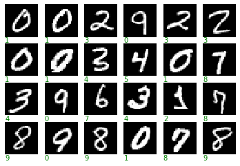

```python
print("MNIST")
plot_some_samples(x_mnist_train, y_mnist_train, ncols=6, nrows=4);
```

```
Fashion-MNIST
```

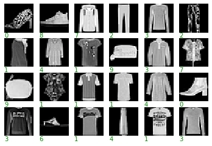

```python
print("Fashion-MNIST")
plot_some_samples(x_fashion_mnist_train, y_fashion_mnist_train, ncols=6, nrows=4);
```

#### Exercise 1.3

Prepare for training.

```python
# One hot encoding of the labels for MNIST
y_mnist_train_1hot = to_categorical(y_mnist_train)
y_mnist_val_1hot = to_categorical(y_mnist_val)

print("MNIST:")
for i in range(5):
    print("train : {0} => {1} \ttest : {2} => {3}".format(y_mnist_train[i], y_mnist_train_1hot[i], y_mnist_val[i], y_mnist_val_1hot[i]))
```

```
MNIST:
train : 5 => [0. 0. 0. 0. 0. 1. 0. 0. 0. 0.] 	test : 7 => [0. 0. 0. 0. 0. 0. 0. 1. 0. 0.]
train : 0 => [1. 0. 0. 0. 0. 0. 0. 0. 0. 0.] 	test : 2 => [0. 0. 1. 0. 0. 0. 0. 0. 0. 0.]
train : 4 => [0. 0. 0. 0. 1. 0. 0. 0. 0. 0.] 	test : 1 => [0. 1. 0. 0. 0. 0. 0. 0. 0. 0.]
train : 1 => [0. 1. 0. 0. 0. 0. 0. 0. 0. 0.] 	test : 0 => [1. 0. 0. 0. 0. 0. 0. 0. 0. 0.]
train : 9 => [0. 0. 0. 0. 0. 0. 0. 0. 0. 1.] 	test : 4 => [0. 0. 0. 0. 1. 0. 0. 0. 0. 0.]
```

```python
# One hot encoding of the labels for Fashion MNIST
y_fashion_mnist_train_1hot = to_categorical(y_fashion_mnist_train)
y_fashion_mnist_val_1hot = to_categorical(y_fashion_mnist_val)

print("Fashion MNIST:")
for i in range(5):
    print("train : {0} => {1} \ttest : {2} => {3}".format(y_fashion_mnist_train[i], y_fashion_mnist_train_1hot[i], y_fashion_mnist_val[i], y_fashion_mnist_val_1hot[i]))
```

```
Fashion MNIST:
train : 9 => [0. 0. 0. 0. 0. 0. 0. 0. 0. 1.] 	test : 9 => [0. 0. 0. 0. 0. 0. 0. 0. 0. 1.]
train : 0 => [1. 0. 0. 0. 0. 0. 0. 0. 0. 0.] 	test : 2 => [0. 0. 1. 0. 0. 0. 0. 0. 0. 0.]
train : 0 => [1. 0. 0. 0. 0. 0. 0. 0. 0. 0.] 	test : 1 => [0. 1. 0. 0. 0. 0. 0. 0. 0. 0.]
train : 3 => [0. 0. 0. 1. 0. 0. 0. 0. 0. 0.] 	test : 1 => [0. 1. 0. 0. 0. 0. 0. 0. 0. 0.]
train : 0 => [1. 0. 0. 0. 0. 0. 0. 0. 0. 0.] 	test : 6 => [0. 0. 0. 0. 0. 0. 1. 0. 0. 0.]
```

```python
# Rescale the input data into the range [0,1] for MNIST
max_grey_value = 255.0

print("MNIST")
print("Max value in initial dataset (train/test):", np.max(x_mnist_train), np.max(x_mnist_val))
print("Min value in initial dataset (train/test):", np.min(x_mnist_train), np.min(x_mnist_val))
x_mnist_train = x_mnist_train / max_grey_value
x_mnist_val = x_mnist_val / max_grey_value
print("Max value in rescaled dataset (train/test):", np.max(x_mnist_train), np.max(x_mnist_val))
print("Min value in rescaled dataset (train/test):", np.min(x_mnist_train), np.min(x_mnist_val))
```

```
MNIST
Max value in initial dataset (train/test): 255 255
Min value in initial dataset (train/test): 0 0
Max value in rescaled dataset (train/test): 1.0 1.0
Min value in rescaled dataset (train/test): 0.0 0.0
```

```python
# MNIST: rescale the input data into the range [0,1] for Fashion MNIST
print("Fashion-MNIST")
print("Max value in initial dataset (train/test):", np.max(x_fashion_mnist_train), np.max(x_fashion_mnist_val))
print("Min value in initial dataset (train/test):", np.min(x_fashion_mnist_train), np.min(x_fashion_mnist_val))
x_fashion_mnist_train = x_fashion_mnist_train / max_grey_value
x_fashion_mnist_val = x_fashion_mnist_val / max_grey_value
print("Max value in rescaled dataset (train/test):", np.max(x_fashion_mnist_train), np.max(x_fashion_mnist_val))
print("Min value in rescaled dataset (train/test):", np.min(x_fashion_mnist_train), np.min(x_fashion_mnist_val))
```

```
Fashion-MNIST
Max value in initial dataset (train/test): 255 255
Min value in initial dataset (train/test): 0 0
Max value in rescaled dataset (train/test): 1.0 1.0
Min value in rescaled dataset (train/test): 0.0 0.0
```

```python
# Reshape (flatten) the input images to input vectors for MNIST
print("MNIST")
original_mnist_train_shape = x_mnist_train.shape
original_mnist_val_shape = x_mnist_val.shape
x_mnist_train_flat = x_mnist_train.reshape(x_mnist_train.shape[0], x_mnist_train.shape[1]*x_mnist_train.shape[2])
x_mnist_val_flat = x_mnist_val.reshape(x_mnist_val.shape[0], x_mnist_val.shape[1]*x_mnist_val.shape[2])
print("Reshaped training data from {0} to {1}".format(original_mnist_train_shape, x_mnist_train_flat.shape))
print("Reshaped validation data from {0} to {1}".format(original_mnist_val_shape, x_mnist_val_flat.shape))
```

```
MNIST
Reshaped training data from (60000, 28, 28) to (60000, 784)
Reshaped validation data from (10000, 28, 28) to (10000, 784)
```

```python
# Reshape (flatten) the input images to input vectors for Fashion MNIST
print("Fashion-MNIST")
original_train_shape = x_fashion_mnist_train.shape
original_val_shape = x_fashion_mnist_val.shape
x_fash_mnist_train_flat = x_fashion_mnist_train.reshape(x_fashion_mnist_train.shape[0], x_fashion_mnist_train.shape[1]*x_fashion_mnist_train.shape[2])
x_fash_mnist_val_flat = x_fashion_mnist_val.reshape(x_fashion_mnist_val.shape[0], x_fashion_mnist_val.shape[1]*x_fashion_mnist_val.shape[2])
print("Reshaped training data from {0} to {1}".format(original_train_shape, x_fash_mnist_train_flat.shape))
print("Reshaped validation data from {0} to {1}".format(original_val_shape, x_fash_mnist_val_flat.shape))
```

```
Fashion-MNIST
Reshaped training data from (60000, 28, 28) to (60000, 784)
Reshaped validation data from (10000, 28, 28) to (10000, 784)
```

```python
# Define useful constants
input_dim_mnist = x_mnist_train_flat.shape[1]
input_dim_fash_mnist = x_fash_mnist_train_flat.shape[1]
classes_nb_mnist = y_mnist_train_1hot.shape[1]
classes_nb_fash_mnist = y_fashion_mnist_train_1hot.shape[1]
print("MMNIST : input shape {0}; number of classes {1}".format(input_dim_mnist, classes_nb_mnist))
print("Fashion MMNIST : input shape {0}; number of classes {1}".format(input_dim_fash_mnist, classes_nb_fash_mnist))
```

```
MMNIST : input shape 784; number of classes 10
Fashion MMNIST : input shape 784; number of classes 10
```

## Exercise 2: No hidden layer (10 points)

Define and fit a model without a hidden layer (since we will use multi-layer models later in this project, you can define a general constructor function for models with an arbitrary number of hidden layers already at this point). Note that in this miniproject there is no real test dataset and what is loaded as a test dataset is used for validation. First, implement 1.-3. for the MNIST dataset.

1. Implement the model with the following specifications: use the softmax activation for the output layer, use the categorical_crossentropy loss, choose stochastic gradient descent for the optimizer, and add the accuracy metric to the metrics. (5 pts)
2. Train for as many epochs as needed to see no further decrease in the validation loss. (1 pt)
3. Plot the learning curves resulting from the fitting procedure (a history object) using the function `plot_history` defined above. (1 pt)
4. Repeat the above steps for fitting the network to the Fashion-MNIST dataset. (2 pts)
5. Report the best validation accuracy achieved for each one of the datasets. Do you observe overfitting already for this simple model? Answer separetely for the MNIST dataset and Fashion-MNIST dataset. (1 pt)

*Hint:* Read the keras docs, in particular [Getting started with the Keras Sequential model](https://keras.io/getting-started/sequential-model-guide/).

### Useful functions

```python
def get_save_dir():
  """Get directory where models and histories are saved."""
  save_dir = 'save'
  if os.path.isdir(save_dir) is not True:
    os.mkdir(save_dir)
  return save_dir


def get_path_history(exercise_name):
  """Get path of history file."""
  return os.path.join(get_save_dir(), exercise_name + '_history.npy')


def get_path_model(exercise_name):
  """Get path of model file."""
  return os.path.join(get_save_dir(), exercise_name + '_model.keras')


def get_callbacks(early_stop = True, save_model=False, exercise_name='', verbose=0):
  """
  Return callbacks for fit.

  Parameters:
  early_stop : if true we use early stopping
  save_model : if true we save the model in a file (the exercise_name must be provided)
  exercise_name : the name used to save the model in a file
  """
  callbacks = []

  if save_model:
    save_callback = ModelCheckpoint(get_path_model(exercise_name), monitor='val_loss', mode='min', save_best_only=True, verbose=verbose)
    callbacks.append(save_callback)

  if early_stop:
    stop_callback = EarlyStopping(monitor='val_loss', mode='min', verbose=verbose, patience=20)
    callbacks.append(stop_callback)

  return callbacks


def fit_custom(exercise_name, model, x, y, validation_data=None, batch_size=None, epochs=None, callbacks=None, verbose=0):
  """
  Load saved history or launch fit if it does not exist.

  Parameters:
  - exercise_name: String name of the exercise, it is used to store the history and reload it.
  - model: Keras Model from which fit is applied.

  Others inputs are named in the same way that the Keras fit function, and are directly passed to it:
  - x : Vector, matrix, or array of training data
  - y : Vector, matrix, or array of target (label) data
  - validation_data : Data on which to evaluate the loss and any model metrics at the end of each epoch.
  - batch_size : Integer or NULL. Number of samples per gradient update. If unspecified, batch_size will default to 32.
  - epochs : Number of epochs to train the model.
  - callbacks : List of callbacks to be called during training.
  - verbose : Verbosity mode (0 = silent, 1 = progress bar, 2 = one line per epoch)
  """
  path_history = get_path_history(exercise_name)

  if not os.path.isfile(path_history):
    print("Begin to train the model {0}.".format(exercise_name))
    fit_output = model.fit(
        x=x,
        y=y,
        validation_data=validation_data,
        batch_size=32,
        epochs=epochs,
        callbacks=callbacks,
        verbose=verbose)
    print("Finished training the model {0}.".format(exercise_name))

    # Save history on a file
    history = fit_output.history
    np.save(path_history, history)
  else:
    print("Loading", path_history)
    history = np.load(path_history, allow_pickle='TRUE').item()

  return history


def get_model(input_dim, layers, h, optimizer, lr, dropout = 0, l2 = 0):
    """
    Return a compiled model.

    Parameters:
    - 'input_dim': input dimension
    - 'layers': hidden layers
    - 'h': units in each hidden layer
    - 'optimizer': optimizer
    - "lr': learning rate
    - 'dropout': dropout rate
    - 'l2': L2 regularization factor
    """
    # Clear the session to remove all the nodes left over from previous models.
    # It frees memory and prevent slowdown.
    K.clear_session()

    model = Sequential()
    model.add(Dense(classes_nb_mnist, activation='relu', name="input_layer",  input_shape=(input_dim_mnist,)))

    if(dropout > 0):
      model.add(Dropout(dropout))

    for i in range(layers):
      kernel_regularizer = None
      if(l2>0):
        kernel_regularizer = regularizers.l1_l2(l1=0, l2=l2)

      model.add(Dense(h, activation='relu', kernel_regularizer=kernel_regularizer))

      if(dropout > 0):
        model.add(Dropout(dropout))

    model.add(Dense(classes_nb_mnist, activation='softmax', name="output_layer"))

    model.compile(optimizer=optimizer(lr), loss='categorical_crossentropy', metrics=["accuracy"])

    return model
```

#### Exercise 2.1

Implement the model.

```python
model=get_model(input_dim=input_dim_mnist, layers=0, h=0, optimizer=SGD, lr=0.01)
model.summary()
```

```
Model: "sequential"
_________________________________________________________________
Layer (type)                 Output Shape              Param #
=================================================================
input_layer (Dense)          (None, 10)                7850
_________________________________________________________________
output_layer (Dense)         (None, 10)                110
=================================================================
Total params: 7,960
Trainable params: 7,960
Non-trainable params: 0
_________________________________________________________________
```

#### Exercise 2.2

Train for as many epochs as needed to see no further decrease in the validation loss.

```python
exercise_name='ex_2.2'
history_mnist = fit_custom(
    exercise_name=exercise_name,
    model=model,
    x=x_mnist_train_flat,
    y=y_mnist_train_1hot,
    validation_data=(x_mnist_val_flat, y_mnist_val_1hot),
    epochs=100,
    callbacks=get_callbacks(early_stop = True, save_model=False, exercise_name=exercise_name),
    verbose=1)
```

```
Loading save/ex_2.2_history.npy
```

#### Exercise 2.3

Plot the learning curves resulting from the fitting procedure (a history object) using the function `plot_history` defined above.

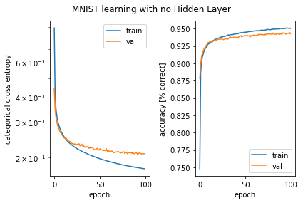

```python
plot_history_custom(history_mnist, "MNIST learning with no Hidden Layer");
```

#### Exercise 2.4

Repeat with the Fashion-MNIST dataset.

```python
model=get_model(input_dim=input_dim_fash_mnist, layers=0, h=0, optimizer=SGD, lr=0.01)
model.summary()
```

```
Model: "sequential"
_________________________________________________________________
Layer (type)                 Output Shape              Param #
=================================================================
input_layer (Dense)          (None, 10)                7850
_________________________________________________________________
output_layer (Dense)         (None, 10)                110
=================================================================
Total params: 7,960
Trainable params: 7,960
Non-trainable params: 0
_________________________________________________________________
```

```python
exercise_name = 'ex_2.4'
history_fash_mnist = fit_custom(
    exercise_name=exercise_name,
    model=model,
    x=x_fash_mnist_train_flat,
    y=y_fashion_mnist_train_1hot,
    validation_data=(x_fash_mnist_val_flat, y_fashion_mnist_val_1hot),
    epochs=100,
    callbacks=get_callbacks(early_stop = True, save_model=False, exercise_name=exercise_name),
    verbose=1)
```

```
Loading save/ex_2.4_history.npy
```

[figure not shown]

```python
plot_history_custom(history_mnist, "Fashion-MNIST learning with no hidden layer ");
```

#### Exercise 2.5

Report the best validation accuracy achieved for each one of the datasets. Do you observe overfitting already for this simple model? Answer separetely for the MNIST dataset and Fashion-MNIST dataset. (1 pt)

```python
print("Best validation accuracies for MNIST learning with no Hidden Layer: {0}.".format(round(max(history_mnist["val_accuracy"]), 2)))
print("Best validation accuracies for Fashion-MNIST learning with no Hidden Layer: {0}.".format(round(max(history_fash_mnist["val_accuracy"]), 2)))
```

```
Best validation accuracies for MNIST learning with no Hidden Layer: 0.94.
Best validation accuracies for Fashion-MNIST learning with no Hidden Layer: 0.86.
```

**Answer to Question 5** (max 2 sentences):  
*MNIST:*  
We don't see overfitting on MNIST with this simple model. If overfitting would be present, we should see the validation loss stopping to decrease and begin to increase. The highest validation accuracy on the MNIST dataset is 94%.

*Fashion-MNIST:*  
We also don't see overfitting on the Fashion-MNIST. The highest validation accuracy achieved by the model on the MNIST Fashion dataset is 86%.

## Exercise 3: One hidden layer, different optimizers (10 points)

Train a network with one hidden layer and compare different optimizers for the MNIST dataset.

1. Use one hidden layer with 128 units and the 'relu' activation. Use the [summary method](https://keras.io/api/models/model/#summary-method) to display your model in a compact way. (1 pt)
2. Train the model for at least 50 epochs with different learning rates of stochastic gradient descent (SGD). What happens if the learning rate $\eta$ is very large (for ex. $\eta=1$), and very small (for ex. $\eta=0.001$)? Comment on the fluctuations of the learning curve. (2 pts)
3. Replace the stochastic gradient descent optimizer with the [Adam optimizer](https://keras.io/optimizers/#adam) (you can use the default learning rate). (1pt)
4. Plot the learning curves of SGD with a good learning rate (i.e. in the range [0.01,0.1]) together with the learning curves of Adam in the same figure. Take care of a reasonable labeling of the curves in the plot. (1 pts)
5. Explain the qualitative difference between the loss and accuracy curves with respect to signs of overfitting. Report the best validation accuracy achieved for SGD and Adam. Which one is better and why do you think so? (2 pts)
6. Determine the indices of all test images that are misclassified by the fitted model and plot some of them using the function `plot_some_samples`. (1 pt)

Real-world datasets are labeled by some people and sometimes there are mistakes in the labeling. We will corrupt labels of the MNIST dataset artifically, and observe an overfitting to this noisy dataset with Adam.

1. Take $ p = 0.2 $ fraction of the data points from the training dataset of MNIST and change their class labels randomly. (You can sample a random integer from 0 to 9 using `np.random.uniform` and `np.floor`). Train with Adam for 50 or 100 epochs. Plot the learning curves. Do you observe overfitting in the validation accuracy? Does it take longer to converge to perfect training accuracy compare to noise-free MNIST? (2 pts)

### Useful functions

```python
def train_with_various_lr(exercise_name, model, learning_rates, optimizer):
  """Train with various learning rates."""
  histories = []

  for lr in learning_rates:
    name = exercise_name + '_lr_{0}'.format(lr)
    history = fit_custom(
          exercise_name=name,
          model=model(lr),
          x=x_mnist_train_flat,
          y=y_mnist_train_1hot,
          validation_data=(x_mnist_val_flat, y_mnist_val_1hot),
          epochs=100,
          callbacks=get_callbacks(early_stop = False, save_model=True, exercise_name=name),
          verbose=1)

    # Get optimizer name for plotting
    optimizer_name = str(optimizer).split(".")[-1].replace('>', '').replace("'", "")

    plot_history_custom(
        history,
        "MNIST learning with {0} and learning rate {1}".format(optimizer_name,lr));

    histories.append(history)

  return histories

def comparison_plot_custom(history_1, history_2, label1, label2, title):
  """Plot to compare two histories."""
  fig, ax1, ax2 = prepare_standardplot(title, "epochs")
  ax1.plot(history_1['loss'], label=label1 + ' train')
  ax1.plot(history_1['val_loss'], label=label1 + ' val')
  ax1.plot(history_2['loss'], label=label2 + ' train')
  ax1.plot(history_2['val_loss'], label=label2 + ' val')
  ax2.plot(history_1['accuracy'], label=label1 + ' train')
  ax2.plot(history_1['val_accuracy'], label=label1 + ' val')
  ax2.plot(history_2['accuracy'], label=label2 + ' train')
  ax2.plot(history_2['val_accuracy'], label=label2 + ' val')
  finalize_standardplot(fig, ax1, ax2)
  return fig

def noise_labels(y_hot, p):
  """Noise one hot labels according to the fraction 'p'."""
  length = y_hot.shape[0]
  number_of_classes = y_hot.shape[1]

  # Define indices to noise
  indices = np.arange(length)
  noise_number_mnist = int(length*p)
  noisy_indices = choice(indices, noise_number_mnist)

  # Generate noisy labels
  y_1hot_noisy = y_hot.copy()
  for index in noisy_indices:
    class_index = np.floor(np.random.uniform(0,number_of_classes-0.01))
    y_1hot_noisy[index] = to_categorical(class_index, num_classes=classes_nb_mnist)

  return y_1hot_noisy
```

#### Exercise 3.1

Use one hidden layer with 128 units and the 'relu' activation. Use the [summary method](https://keras.io/api/models/model/#summary-method) to display your model in a compact way.

```python
def get_model_ex_3_1(learning_rate):
  """Create a model with 1 hidden layer and 128 units, compiled with SGD optimizer."""
  return get_model(input_dim=input_dim_mnist, layers=1, h=128, optimizer=SGD, lr=learning_rate)

# Display a model summary with an arbitrary learning rate
get_model_ex_3_1(0.01).summary()
```

```
Model: "sequential"
_________________________________________________________________
Layer (type)                 Output Shape              Param #
=================================================================
input_layer (Dense)          (None, 10)                7850
_________________________________________________________________
dense (Dense)                (None, 128)               1408
_________________________________________________________________
output_layer (Dense)         (None, 10)                1290
=================================================================
Total params: 10,548
Trainable params: 10,548
Non-trainable params: 0
_________________________________________________________________
```

#### Exercise 3.2

Train the model for at least 50 epochs with different learning rates of stochastic gradient descent (SGD). What happens if the learning rate 𝜂 is very large (for ex. 𝜂=1), and very small (for ex. 𝜂=0.001)? Comment on the fluctuations of the learning curve.

```
Loading save/ex_3.2_lr_1_history.npy
Loading save/ex_3.2_lr_0.1_history.npy
Loading save/ex_3.2_lr_0.01_history.npy
Loading save/ex_3.2_lr_0.001_history.npy
```

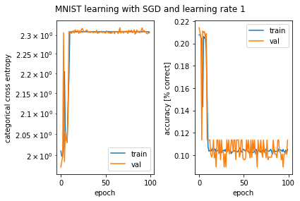

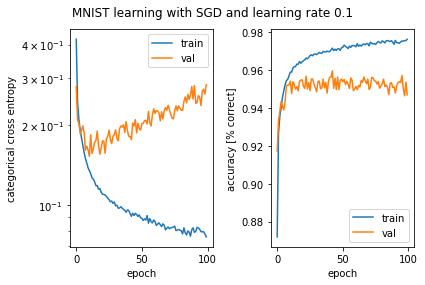

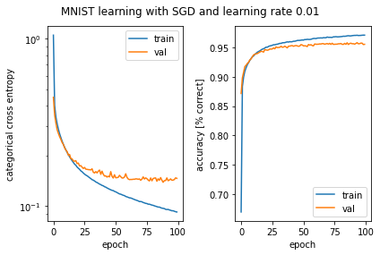

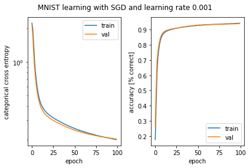

```python
learning_rates = [10**(-e) for e in range(0,4)]

histories_sgd = train_with_various_lr( exercise_name='ex_3.2', model=get_model_ex_3_1, learning_rates=learning_rates, optimizer=SGD)
```

**Answer to Question 2** (max 2 sentences): The fluctuations of the learning curves are decreasing with decreasing learning rate (for small learning rates. This can be explained by the fact that for smaller learning rates, the weight updates are smaller leading to less fluctuations.

#### Exercise 3.3

Replace the stochastic gradient descent optimizer with the [Adam optimizer](https://keras.io/optimizers/#adam) (you can use the default learning rate).

```python
def get_model_ex_3_3(learning_rate):
  """Create a model with 1 hidden layer and 128 units, compiled with Adam optimizer."""
  return get_model(input_dim=input_dim_mnist, layers=1, h=128, optimizer=Adam, lr=learning_rate)
```

```
Loading save/ex_3.3_lr_0.001_history.npy
```

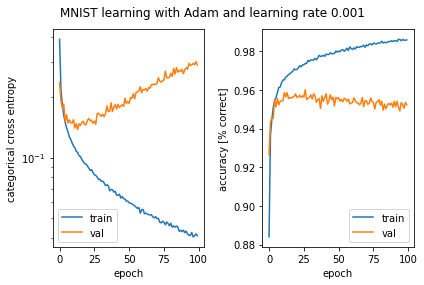

```python
adam_lr = 0.001
histories_adam = train_with_various_lr(
    exercise_name='ex_3.3',
    model = get_model_ex_3_3,
    learning_rates=[adam_lr],
    optimizer=Adam)
```

#### Exercise 3.4

Plot the learning curves of SGD with a good learning rate (i.e. in the range [0.01,0.1]) together with the learning curves of Adam in the same figure. Take care of a reasonable labeling of the curves in the plot.

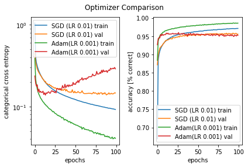

```python
sgd_lr = 0.01
history_good_sgd = histories_sgd[learning_rates.index(sgd_lr)]

comparison_plot_custom(
    history_good_sgd,
    histories_adam[0],
    "SGD (LR {0})".format(sgd_lr),
    "Adam(LR {0})".format(adam_lr),
    "Optimizer Comparison");
```

#### Exercise 3.5

Explain the qualitative difference between the loss and accuracy curves with respect to signs of overfitting. Report the best validation accuracy achieved for SGD and Adam. Which one is better and why do you think so?

(Answered on the specific section, previously.)

```python
print("Best validation accuracies:")
print("- SGD: {0}.".format(round(max(history_good_sgd["val_accuracy"]), 2)))
print("- Adam: {0}.".format(round(max(histories_adam[0]["val_accuracy"]), 2)))
```

```
Best validation accuracies:
- SGD: 0.96.
- Adam: 0.96.
```

**Answer to Question 5** (max 3 sentences): The model using the Adam optimizer (lr: 0.001) learns faster and its validation accuracy levels out after around 10 epochs and then it is overfitting. The model using SGD (lr: 0.01) does not really overfit and the training takes longer. The accuracies are similar, but we would prefer Adam to learn faster.

### Exercise 3.6

Determine the indices of all test images that are misclassified by the fitted model and plot some of them using the function `plot_some_samples`.

```python
model_sgd = load_model('./save/ex_3.2_lr_0.01_model.keras', compile=True);
model_adam =load_model('./save/ex_3.3_lr_0.001_model.keras', compile=True);
```

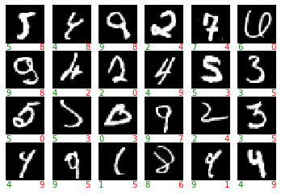

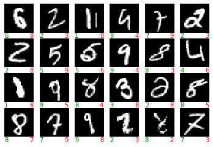

```python
models = [model_sgd, model_adam]

for model in models:
    y_pred = model.predict_on_batch(x_mnist_val_flat).argmax(axis=1)
    indices = [i for i,v in enumerate(y_pred) if y_pred[i]!=y_mnist_val[i]]

    x_wrongly_predicted = np.asarray([x_mnist_val_flat[i] for i in indices])
    y_wrongly_predicted = np.asarray([y_pred[i] for i in indices])
    y_true_prediction = np.asarray([y_mnist_val[i] for i in indices])

    plot_some_samples_custom(x_wrongly_predicted, y_true_prediction, y_wrongly_predicted, ncols=6, nrows=4);
```

#### Exercise 3.7

Take $ p = 0.2 $ fraction of the data points from the training dataset of MNIST and change their class labels randomly. (You can sample a random integer from 0 to 9 using `np.random.uniform` and `np.floor`). Train with Adam for 50 or 100 epochs. Plot the learning curves. Do you observe overfitting in the validation accuracy? Does it take longer to converge to perfect training accuracy compare to noise-free MNIST? (2 pts)

```python
# Train with noisy labels
y_mnist_train_1hot_noisy = noise_labels(y_mnist_train_1hot, p=0.2)

history_adam_noisy = fit_custom('ex_3.7_lr_{0}'.format(adam_lr),
                                model=model,
                                x=x_mnist_train_flat,
                                y=y_mnist_train_1hot_noisy,
                                validation_data=(x_mnist_val_flat, y_mnist_val_1hot),
                                epochs=100,
                                callbacks=None,
                                verbose=1
)
```

```
Loading save/ex_3.7_lr_0.001_history.npy
```

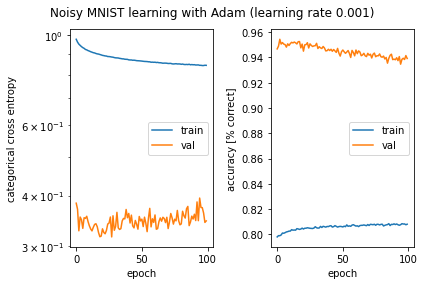

```python
plot_history_custom(history_adam_noisy, "Noisy MNIST learning with Adam (learning rate {0})".format(adam_lr));
```

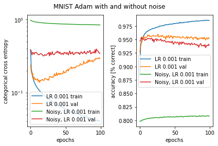

```python
comparison_plot_custom(
    histories_adam[0],
    history_adam_noisy,
    "LR {0}".format(adam_lr),
    "Noisy, LR {0}".format(adam_lr),
    "MNIST Adam with and without noise");
```

**Answer to Question 7** (max 2 sentences): In normal and noisy case, there is overfitting. The noisy dataset begins to overfit sooner (after around 5 epochs) but its results are worth.

## Exercise 4: Model performance as a function of number of hidden neurons (8 + 2 points)

Since the MNIST dataset is almost perfectly solved already by a one-hidden-layer network in Exercise 3, we use the Fashion-MNIST dataset from now on to compare the performances of more complex models. In this exercise, we investigate how the best validation loss and accuracy depends on the number of hidden neurons in a single layer.

1. Fit at least 4 models with different number of hidden neurons (i.e. width) between 10 and 1000 to the Fashion-MNIST dataset. Train with Adam for 50-100 epochs. (2 pts)
2. Plot the best validation loss and accuracy versus the width. Is the observed trend in accordance with the [general approximation theorem](https://en.wikipedia.org/wiki/Universal_approximation_theorem)? Do you observe an overfitting due to the complexity of the wider networks with more parameters? Report the best validation accuracy. (2 pts)
3. Choose $ p \geq 0.5 $ fraction of the data points from the training dataset of Fashion-MNIST and change their class labels randomly as in Exercise 3. For this noisy Fashion-MNIST dataset, fit at least 4 models with different widths between 10 and 250. Train with Adam for at least 150 epochs. Plot the best validation loss and accuracy vs. width. (2 pts)
4. BONUS: Add random Gaussian noise on the input pixels with mean 0 and variance between 0.01-0.5 and use the original labels. For this noisy Fashion-MNIST dataset, fit at least 4 models with different widths between 10 and 250. Train with Adam for at least 150 epochs. Plot the best validation loss and accuracy vs. width. (2 pts)
5. Answer to the same questions in 2 for the noisy Fashion-MNIST dataset(s). Comment on the differences between width-performence curves for these two (or three) datasets. (2 pts)

In this exercise we fit each model only for one initialization and random seed. In practice one would collect some statistics (e.g. 25-, 50-, 75-percentiles) for each layer size by fitting each model several times with different initializations and the random seeds. You may also want to do this here. It is a good exercise, but not mandatory as it takes quite a bit of computation time.

#### Useful functions

```python
def train_adam_different_neurons_nb(exercise_name, x, y, validation_data, numbers_of_hidden_neurons=[10, 50, 100, 500, 1000], epochs=50, lr=0.001):
  """Train with Adam with various number of hidden neurons."""
  histories=[]
  metrics = {"neurons":[], "min_loss":[], "min_val_loss":[], "max_accuracy":[], "max_val_accuracy":[]}

  for number_of_hidden_neurons in numbers_of_hidden_neurons:
    model = get_model(input_dim=input_dim_fash_mnist, layers=1, h=number_of_hidden_neurons, optimizer=Adam, lr=lr)
    history = fit_custom(exercise_name + "_ANN-with-{0}-hidden-neurons".format(number_of_hidden_neurons),
                        model=model, epochs=epochs,
                        x=x,
                        y=y,
                        validation_data=validation_data,
                        callbacks=get_callbacks(early_stop = False, save_model=False),
                        verbose=0)
    histories.append(history)

    metrics["neurons"].append(number_of_hidden_neurons)
    metrics["min_loss"].append(min(history["loss"]))
    metrics["min_val_loss"].append(min(history["val_loss"]))
    metrics["max_accuracy"].append(max(history["accuracy"]))
    metrics["max_val_accuracy"].append(max(history["val_accuracy"]))

  return histories, metrics


def plot_metrics(metrics):
  """Plot given metrics."""
  fig, (ax1, ax2) = plt.subplots(1, 2)
  fig.suptitle('Validation loss and accuracy / number of hidden neurons')
  fig.subplots_adjust(left=None, bottom=None, right=None, top=None, wspace=0.3, hspace=None)
  fig.set_figheight(6)
  fig.set_figwidth(12)

  ax1.set_xscale('log')
  ax1.set_ylabel("Validation loss")
  ax1.set_xlabel("number of hidden neurons")
  ax1.plot(metrics["neurons"], metrics["min_loss"], label = "train")
  ax1.plot(metrics["neurons"], metrics["min_val_loss"], label = "val")

  ax2.set_xscale('log')
  ax2.set_ylabel("Validation accuracy")
  ax2.set_xlabel("number of hidden neurons")
  ax2.plot(metrics["neurons"], metrics["max_accuracy"], label = "train");
  ax2.plot(metrics["neurons"], metrics["max_val_accuracy"], label = "val");

  finalize_standardplot(fig, ax1, ax2)
```

#### Exercise 4.1

Fit at least 4 models with different number of hidden neurons (i.e. width) between 10 and 1000 to the Fashion-MNIST dataset. Train with Adam for 50-100 epochs. (2 pts)

```python
histories, metrics = train_adam_different_neurons_nb(
    exercise_name="ex_4.1",
    x=x_fash_mnist_train_flat,
    y=y_fashion_mnist_train_1hot,
    validation_data=(x_fash_mnist_val_flat, y_fashion_mnist_val_1hot),
    numbers_of_hidden_neurons=[10, 50, 100, 500, 1000],
    epochs=50,
    lr=adam_lr)
```

```
Loading save/ex_4.1_ANN-with-10-hidden-neurons_history.npy
Loading save/ex_4.1_ANN-with-50-hidden-neurons_history.npy
Loading save/ex_4.1_ANN-with-100-hidden-neurons_history.npy
Loading save/ex_4.1_ANN-with-500-hidden-neurons_history.npy
Loading save/ex_4.1_ANN-with-1000-hidden-neurons_history.npy
```

#### Exercise 4.2

Plot the best validation loss and accuracy versus the width. Is the observed trend in accordance with the general approximation theorem? Do you observe an overfitting due to the complexity of the wider networks with more parameters? Report the best validation accuracy. (2 pts)

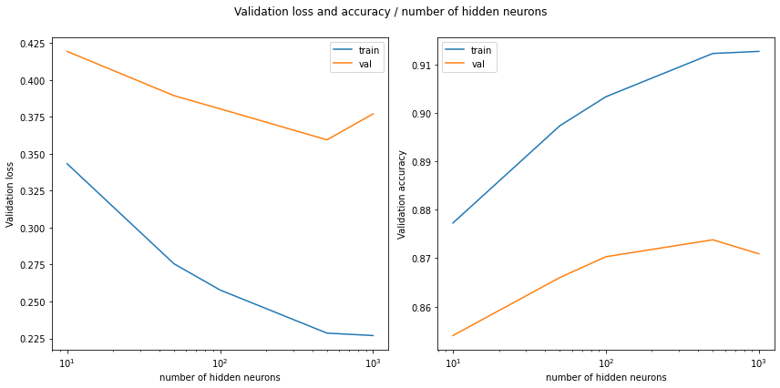

```python
plot_metrics(metrics)
```

**Answer to Question 2** (max 2 sentences): The Universal Approximation Theorem states that a neural network with one hidden layer and unlimited number of hidden neurons can approximate any continuous function for inputs within a specific range and this can also be observed with our example, since the best training accuracy is steadily increasing with the number of hidden neurons. It appears that after about 500 neurons, the best accuracy decreases, meaning that we overfit.

#### Exercise 4.3

Choose $ p \geq 0.5 $ fraction of the data points from the training dataset of Fashion-MNIST and change their class labels randomly as in Exercise 3. For this noisy Fashion-MNIST dataset, fit at least 4 models with different widths between 10 and 250. Train with Adam for at least 150 epochs. Plot the best validation loss and accuracy vs. width. (2 pts)

```python
numbers_of_hidden_neurons=[10, 50, 100, 150, 200, 250]

histories, metrics = train_adam_different_neurons_nb(
    exercise_name="ex_4.3",
    x=x_fash_mnist_train_flat,
    y=noise_labels(y_fashion_mnist_train_1hot, p=0.5),
    validation_data=(x_fash_mnist_val_flat, y_fashion_mnist_val_1hot),
    numbers_of_hidden_neurons=numbers_of_hidden_neurons,
    epochs=150,
    lr=adam_lr)
```

```
Loading save/ex_4.3_ANN-with-10-hidden-neurons_history.npy
Loading save/ex_4.3_ANN-with-50-hidden-neurons_history.npy
Loading save/ex_4.3_ANN-with-100-hidden-neurons_history.npy
Loading save/ex_4.3_ANN-with-150-hidden-neurons_history.npy
Loading save/ex_4.3_ANN-with-200-hidden-neurons_history.npy
Loading save/ex_4.3_ANN-with-250-hidden-neurons_history.npy
```

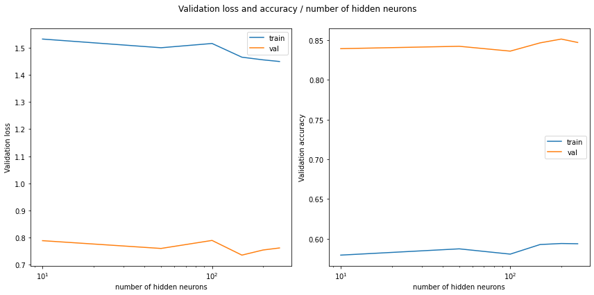

```python
plot_metrics(metrics)
```

### Exercise 4.4

Add random Gaussian noise on the input pixels with mean 0 and variance between 0.01-0.5 and use the original labels. For this noisy Fashion-MNIST dataset, fit at least 4 models with different widths between 10 and 250. Train with Adam for at least 150 epochs. Plot the best validation loss and accuracy vs. width. (2 pts)

```python
# Noise  pixels
x_fash_mnist_train_flat_noisy = x_fash_mnist_train_flat + normal(loc=0,scale=0.05,size=(x_fash_mnist_train_flat.shape))
```

```python
_, metrics = train_adam_different_neurons_nb(
    exercise_name="ex_4.4",
    x=x_fash_mnist_train_flat_noisy,
    y=y_fashion_mnist_train_1hot,
    validation_data=(x_fash_mnist_val_flat, y_fashion_mnist_val_1hot),
    numbers_of_hidden_neurons=numbers_of_hidden_neurons,
    epochs=150,
    lr=adam_lr)
```

```
Loading save/ex_4.4_ANN-with-10-hidden-neurons_history.npy
Loading save/ex_4.4_ANN-with-50-hidden-neurons_history.npy
Loading save/ex_4.4_ANN-with-100-hidden-neurons_history.npy
Loading save/ex_4.4_ANN-with-150-hidden-neurons_history.npy
Loading save/ex_4.4_ANN-with-200-hidden-neurons_history.npy
Loading save/ex_4.4_ANN-with-250-hidden-neurons_history.npy
```

[figure not shown]

[figure not shown]

[figure not shown]

[figure not shown]

[figure not shown]

[figure not shown]

```python
for i in range(len(numbers_of_hidden_neurons)):
  plot_history_custom(histories[i], "{0} hidden neurons".format(numbers_of_hidden_neurons[i]));
```

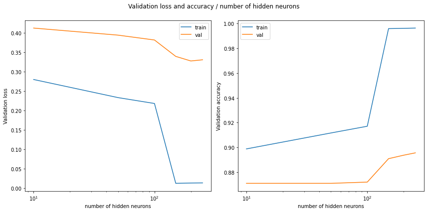

```python
plot_metrics(metrics)
```

### Exercise 4.5

Is the observed trend in accordance with the general approximation theorem? Do you observe an overfitting due to the complexity of the wider networks with more parameters? Report the best validation accuracy. Comment on the differences between width-performence curves for these two (or three) datasets. (2 pts)

## Exercise 5: Going deeper: tricks and regularization (10 + 2 points)

Adding hidden layers to a deep network does not necessarily lead to a straight-forward improvement of performance. We use Fashion-MNIST dataset in this exercise.

1. Choose a width $ h $ between 50-200 and use at least two hidden layers with $ h $ hidden neurons (each) and train the network for at least 150 epochs. (2 pts)
2. Plot the learning curves and report the best validation accuracy. Do you observe overfitting? (2 pts)
3. Keep the network at the same size. Use a very large l2 regularization $\lambda$ (for ex. $\lambda=1$) and a small one (for ex. $\lambda=0.001$) on kernel weights and report the validation accuracies. What do you observe? (2 pts)
4. Turn off the $ \ell_2 $ regularization and use a large dropout rate (for ex. 0.5) and a small one (for ex. 0.05) at all hidden layers and report the validation accuracies. What do you observe? (2 pts)
5. BONUS: Try built-in data augmentation methods as a way to regularize: this may include horizontal flipping of the images or small rotations. You can use built-in methods in Keras. Report the augmentation method you used and the best validation accuracy. (2 pts)

Note that one needs to cross-validate to find the right regularization parameter for the model you chose and for the dataset at hand. However we do not enforce this hyperparameter search as it takes long computation times but it is a good practice if you try it here.

1. Compare the validation accuracies resulting from your attempts to reduce overfitting. Did you improve the validation accuracy? If not, comment on the possible sources of failure. (2 pts)

### Solution

#### Useful functions

```python
def unison_shuffled(a, b):
    """Shuffle both inputs along first axis in the same way."""
    assert len(a) == len(b)
    p = np.random.permutation(len(a))
    return a[p], b[p]

def add_channel_to_images(images):
  """Add a color channel with depth 1 for all images of the dataset."""
  new_shape = (-1, images.shape[1], images.shape[2], 1)
  return np.reshape(images, new_shape)

def get_augmented_images_generator(images, labels, batch_size):
  """Return an image generator for data augmentation."""
  data_gen_args = dict(featurewise_center=False,
                    featurewise_std_normalization=False,
                    rotation_range=15,
                    width_shift_range=0.1,
                    height_shift_range=0.1,
                    horizontal_flip=True)

  # set channel depth at 1
  images = add_channel_to_images(images)

  image_datagen = ImageDataGenerator(**data_gen_args)
  image_datagen.fit(images, augment=True)
  image_generator = image_datagen.flow(images, labels, batch_size=batch_size)

  return image_generator
```

#### Exercise 5.1

Choose a width $ h $ between 50-200 and use at least two hidden layers with $ h $ hidden neurons (each) and train the network for at least 150 epochs.

```python
h = 128
history = fit_custom(
    exercise_name='ex_5.2_h_{0}'.format(h),
    model=get_model(input_dim=input_dim_mnist, layers=2, h=h, optimizer=SGD, lr=0.01),
    x=x_fash_mnist_train_flat,
    y=y_fashion_mnist_train_1hot,
    validation_data=(x_fash_mnist_val_flat, y_fashion_mnist_val_1hot),
    epochs=150,
    verbose=1
)
```

```
Loading save/ex_5.2_h_128_history.npy
```

#### Exercise 5.2

Plot the learning curves and report the best validation accuracy. Do you observe overfitting?

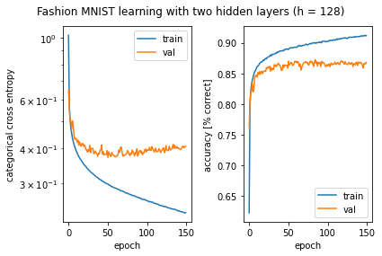

```python
plot_history_custom(history, "Fashion MNIST learning with two hidden layers (h = {0})".format(h));
```

```python
print("For Fashion MNIST learning with two hidden layers (h = {0}), the best validation accuracy is {0}.".format(h, round(max(history["val_accuracy"]), 2)))
```

[output not shown]

**Answer to Question 2** (max 1 sentence):  
Best validation accuracy for Fashion MNIST learning with two hidden layers (h = 128): 0.87.

Overfitting can be observed in the training process since the loss is decreasing but the validation loss is increasing and the validation accuracy levels out after 25 epochs although the training accuracy still keeps increasing.

#### Exercise 5.3

Keep the network at the same size. Use a very large l2 regularization $\lambda$ (for ex. $\lambda=1$) and a small one (for ex. $\lambda=0.001$) on kernel weights and report the validation accuracies. What do you observe?

```python
l2 = 1
history = fit_custom(exercise_name='ex_5.3.1_h_{0}_l2_{1}'.format(h, l2),
                     model=get_model(input_dim=input_dim_mnist, layers=2, h=h, optimizer=SGD, lr=0.01, l2=0),
                     x=x_fash_mnist_train_flat,
                     y=y_fashion_mnist_train_1hot,
                     validation_data=(x_fash_mnist_val_flat, y_fashion_mnist_val_1hot),
                     epochs=150,
                     verbose=1
)
```

```
Loading save/ex_5.3.1_h_128_l2_1_history.npy
```

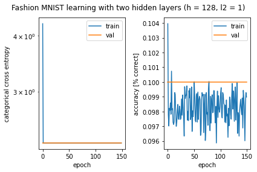

```python
plot_history_custom(history, "Fashion MNIST learning with two hidden layers (h = {0}, l2 = {1})".format(h, l2));
```

```python
print("With l2 regularization (lambda = {0}), the best validation accuracy is {1}.".format(l2, round(max(history["val_accuracy"]), 4)))
```

```
With l2 regularization (lambda = 1), the best validation accuracy is 0.1.
```

```python
l2 = 0.001
history = fit_custom(exercise_name='ex_5.3.2_h_{0}_l2_{1}'.format(h, l2),
                     model=get_model(input_dim=input_dim_mnist, layers=2, h=h, optimizer=SGD, lr=0.01, l2=l2),
                     x=x_fash_mnist_train_flat,
                     y=y_fashion_mnist_train_1hot,
                     validation_data=(x_fash_mnist_val_flat, y_fashion_mnist_val_1hot),
                     epochs=150,
                     verbose=1
)
```

```
Loading save/ex_5.3.2_h_128_l2_0.001_history.npy
```

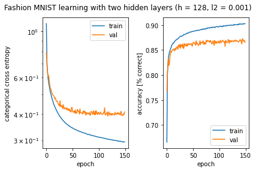

```python
plot_history_custom(history, "Fashion MNIST learning with two hidden layers (h = {0}, l2 = {1})".format(h, l2));
```

```python
print("With l2 regularization (lambda = {0}), the best validation accuracy is {1}.".format(l2, round(max(history["val_accuracy"]), 2)))
```

```
With l2 regularization (lambda = 0.001), the best validation accuracy is 0.87.
```

#### Exercise 5.4

Turn off the $ \ell_2 $ regularization and use a large dropout rate (for ex. 0.5) and a small one (for ex. 0.05) at all hidden layers and report the validation accuracies. What do you observe?

```python
dropout = 0.5
history = fit_custom(
    exercise_name='ex_5.4_h_{0}_dropout_{1}'.format(h, dropout),
    x=x_fash_mnist_train_flat,
    y=y_fashion_mnist_train_1hot,
    validation_data=(x_fash_mnist_val_flat, y_fashion_mnist_val_1hot),
    model=get_model(input_dim=input_dim_mnist, layers=2, h=h, optimizer=SGD, lr=0.01, dropout=dropout),
    epochs=150,
    verbose=1
)
```

```
Loading save/ex_5.4_h_128_dropout_0.5_history.npy
```

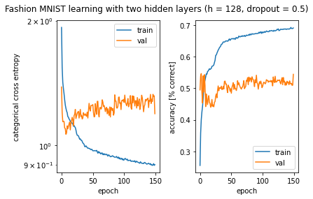

```python
plot_history_custom(history, "Fashion MNIST learning with two hidden layers (h = {0}, dropout = {1})".format(h, dropout));
```

```python
print("With dropout = {0}, the best validation accuracy is {1}.".format(dropout, round(max(history["val_accuracy"]), 2)))
```

```
With dropout = 0.5, the best validation accuracy is 0.55.
```

```python
dropout = 0.05
history = fit_custom(
    exercise_name='ex_5.4_h_{0}_dropout_{1}'.format(h, dropout),
    x=x_fash_mnist_train_flat,
    y=y_fashion_mnist_train_1hot,
    validation_data=(x_fash_mnist_val_flat, y_fashion_mnist_val_1hot),
    model=get_model(input_dim=input_dim_mnist, layers=2, h=h, optimizer=SGD, lr=0.01, dropout=dropout),
    epochs=150,
    verbose=1)
```

```
Loading save/ex_5.4_h_128_dropout_0.05_history.npy
```

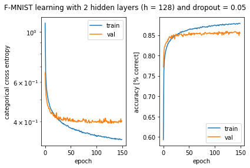

```python
plot_history_custom(history, "F-MNIST learning with 2 hidden layers (h = {0}) and dropout = {1}".format(h, dropout));
```

```python
print("With dropout = {0}, the best validation accuracy is {1}.".format(dropout, round(max(history["val_accuracy"]), 2)))
```

```
With dropout = 0.05, the best validation accuracy is 0.86.
```

**Answer to Question 4** (max 2 sentences): With dropout equals 0.5, the best validation accuracy is 0.55 and with dropout equals 0.05, the best validation accuracy is 0.86. With the dropout at 0.5 the training converges faster (only after 5 epochs), then the learning has no more effect on validation loss (neither accuracy).

#### Exercise 5.5

BONUS: Try built-in data augmentation methods as a way to regularize: this may include horizontal flipping of the images or small rotations. You can use built-in methods in Keras. Report the augmentation method you used and the best validation accuracy. (2 pts)

```python
# Use a small subset of the dataset to visualize the effect of data augmentation
ncols=4
nrows=2
total = ncols * nrows
x_fashion_mnist_train_small = x_fashion_mnist_train[0:total]
y_fashion_mnist_train_1hot_small = y_fashion_mnist_train_1hot[0:total]

image_generator_small = get_augmented_images_generator(x_fashion_mnist_train_small, y_fashion_mnist_train_1hot_small, batch_size=total)
augmented_samples_small = next(image_generator_small)
```

```
Initial images:
```

[figure not shown]

```python
print("Initial images:")
plot_some_samples(x_fashion_mnist_train_small, y_fashion_mnist_train_1hot_small, ncols=ncols, nrows=nrows);
```

```
Modified images:
```

[figure not shown]

```python
print("Modified images:")
plot_some_samples(augmented_samples_small[0], augmented_samples_small[1], ncols=ncols, nrows=nrows);
```

```python
# Generate new data
image_generator = get_augmented_images_generator(
    x_fashion_mnist_train,
    y_fashion_mnist_train_1hot,
    batch_size=x_fashion_mnist_train.shape[0])

augmented_samples = next(image_generator)
print("Generated dataset shape x: {0} / y : {1}".format(augmented_samples[0].shape, augmented_samples[1].shape))

# Flatten images
x_fash_augmented = augmented_samples[0].reshape(x_fashion_mnist_train.shape[0], x_fashion_mnist_train.shape[1]*x_fashion_mnist_train.shape[2])

# Normalize
x_fash_augmented = x_fash_augmented / max_grey_value

y_fash_1hot_augmented = augmented_samples[1]
```

```
Generated dataset shape x: (60000, 28, 28, 1) / y : (60000, 10)
```

```python
# Add to initial dataset
x_fash_augmented = np.concatenate([x_fash_mnist_train_flat, x_fash_augmented])
y_fash_1hot_augmented  = np.concatenate([y_fashion_mnist_train_1hot, y_fash_1hot_augmented])
```

```python
# Schuffle in the same way
x_fash_augmented, y_fash_1hot_augmented = unison_shuffled(x_fash_augmented, y_fash_1hot_augmented)

print("Augmented x training data from {0} to {1}".format(x_fash_mnist_train_flat.shape, x_fash_augmented.shape))
print("Augmented y training data from {0} to {1}".format(y_fashion_mnist_train_1hot.shape, y_fash_1hot_augmented.shape))
```

```
Augmented x training data from (60000, 784) to (120000, 784)
Augmented y training data from (60000, 10) to (120000, 10)
```

```python
history = fit_custom(
    exercise_name = "ex_5.5",
    x=x_fash_augmented,
    y=y_fash_1hot_augmented,
    validation_data=(x_fash_mnist_val_flat, y_fashion_mnist_val_1hot),
    model = get_model(input_dim=input_dim_fash_mnist, layers=2, h=h, optimizer=SGD, lr=0.01),
    epochs=200,
    callbacks=get_callbacks(early_stop=True))
```

```
Loading save/ex_5.5_history.npy
```

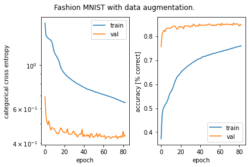

```python
plot_history_custom(history=history, title='Fashion MNIST with data augmentation.');
```

```python
print("With data augmentation, the best validation accuracy is {0}.".format(round(max(history["val_accuracy"]), 2)))
```

```
With data augmentation, the best validation accuracy is 0.85.
```

**Answer to Question 5 (BONUS)** (max 2 sentences): We used the Keras ImageDataGenerator with rotation_range at 15°, width_shift_range 0.1, height_shift_range=0.1 and horizontal_flip. With it, the best validation accuracy is 0.85, so similar to previous ones, but we notice that the learning is longer.

#### Exercise 5.6

Compare the validation accuracies resulting from your attempts to reduce overfitting. Did you improve the validation accuracy? If not, comment on the possible sources of failure. (2 pts)

**Answer to Question 6** (max 2 sentences): We didn't improved the best accuracy, but limited overfitting rise up (when parameters were not too big). Here we tested only few parameters values, but we could mix technics and try to fine tune them to see if we could improve the best accuracy.

## Exercise 6: Convolutional neural networks (CNNs) (10 points)

Convolutional neural networks have an inductive bias that is well adapted to image classification.

1. Design a convolutional neural network and train it without using explicit regularizers. (2 pts)
2. Try to improve the best validation scores of the model by experiment with batch_normalization layers, dropout layers and l2-regularization on weights (kernels) and biases. (4 pts)
3. After you have found good settings, plot the learning curves for both models, naive (=no tricks/regularization) and tuned (=tricks + regularized) together in a comparison plot. (2pts)
4. How does the CNN performance compare to the so far best performing (deep) neural network model? (2 pts)

*Hint:* You may get valuable inspiration from the keras [examples](https://keras.io/examples/), [for example](https://keras.io/examples/vision/mnist_convnet/).

### Solution

#### Useful functions

```python
def add_conv_layer(model, size, kernel_regularizer, bias_regularizer , batch_normalization):
  """Add a convolutional layer."""
  model.add(keras.layers.Conv2D(size, kernel_size=(3, 3), activation='relu',
                              kernel_regularizer=kernel_regularizer))
  if batch_normalization:
    model.add(keras.layers.BatchNormalization())

def add_max_pooling_layer(model, dropout, batch_normalization):
    """Add a max pooling layer."""
    model.add(keras.layers.MaxPooling2D(pool_size=(2, 2)))
    if dropout > 0:
        model.add(keras.layers.Dropout(dropout))

def add_dense_layer(model, size, dropout, kernel_regularizer, bias_regularizer):
    """Add a dense layer."""
    model.add(keras.layers.Dense(size, activation='relu', kernel_regularizer=kernel_regularizer, bias_regularizer=bias_regularizer))
    if dropout > 0:
        model.add(keras.layers.Dropout(dropout))

def get_convolutional_model(input_shape=(28, 28, 1), output_length=10, kernel_l2=1e-4, bias_l2=1e-4, dropout=0.2, batch_normalization=False):
    """
    Build a convolutional neural network.

    We tried several architectures (with similar regularization values):
    a) with 2 * (convolutional layers) => best accuracy between 0.90 and 0.91
    b) with 1 * (convolutional layers) + 1 * (max pooling layer) + 1  *(dense layer) => best accuracy around 0.92
    c) with 3 * (2 convolutional layers + 1 max pooling layer) + 2 * (dense layers) => best accuracy between 0.93 and 0.94

    Here we retained architecture (b) that is a compromise between a good accuracy and simplicity of the network.
    """
    # Clear the session to remove all the nodes left over from previous models, free memory and preventing slowdown.
    K.clear_session()

    # Sequential model
    model = keras.Sequential()

    # Initalize regularizers
    kernel_regularizer = None if not kernel_l2 else regularizers.l2(kernel_l2)
    bias_regularizer= None if not bias_l2 else regularizers.l2(bias_l2)

    # Add convolution layers
    model.add(keras.layers.Conv2D(128, kernel_size=(3, 3), activation='relu', padding='same',
                                  input_shape=input_shape, kernel_regularizer=kernel_regularizer, bias_regularizer=bias_regularizer))

    if batch_normalization:
        model.add(keras.layers.BatchNormalization())

    add_max_pooling_layer(model, dropout, batch_normalization)

    # We flatten before adding a dense layer
    model.add(keras.layers.Flatten())

    # Add dense layers
    add_dense_layer(model, 512, dropout, kernel_regularizer, bias_regularizer)

    # softmax output
    model.add(keras.layers.Dense(output_length, activation='softmax'))

    # Adam optimizer
    adam = Adam(learning_rate=0.001, decay=1e-6)

    # Compile model
    model.compile(optimizer=adam, loss='categorical_crossentropy', metrics=['accuracy'])

    return model
```